# Descriptive Statistics Report

Michał Siemiończyk

10 marca 2017

# Introduction

The task was to analyze the W1_OcenyIlorazIntelZarobki.xlsx dataset.

- for each variable there was a descriptive (summary) analisys to be performed
- the modality of variables distribution has to be checked
- check if the variables have normal distribution
- draw histograms and boxplots and analize its distribution
- check for outstanding values (outliers)
- if there’s a grouping variable
- perform the task for each of them

(in Polish:Przeanalizuj załączone zbiory. Dla każdej zmiennej oblicz statystyki opisowe sprawdź modalność rozkładów sprawdź czy zmienne mają rozkład normalny narysuj histogramy narysuj wykresy “skrzynka z wąsami” i przeanalizuj rozkład, występowanie obserwacji odstających i ekstremalnych Jeśli w danych występuje zmienna grupująca powtórz zadanie w każdej z grup. )

# Dataset

```r
data = read.xls('W1_OcenyIlorazIntelZarobki.xlsx')
```

Dataset consists of 4 variables:

- zarobki - income
- grupa - group (a groupping variable)
- iloraz_intelig - iq
- oceny - grades

```
  grupa oceny iloraz_intelig zarobki
1     A   3.0            109    1500
2     A   3.0            113     600
3     A   2.0             80    3500
4     A   4.0             99    2300
5     A   3.5            101    1800
6     A   2.0            104    1500
```

# Descriptive analisys

```r
source("../functions.R")
```

## Variable “IQ”

### All IQ Data

```r
iqData = data$iloraz_intelig
```

```r
summary(iqData)
```

```
   Min. 1st Qu.  Median    Mean 3rd Qu.    Max.
  67.00   86.25   97.00   97.01  107.20  134.00
```

```r
descriptive_statistics(iqData, "IQ variable")
```

```
variance 194.171616161616
```

```
standard dev 13.9345475764955
```

```
skewness 0.128685339310997 (jeżeli dodatnie to prawy brzeg jest dłuższy, jeżeli ujemne - to lewy)
```

```
kurtoza -0.606481574472046 + : wystaje ponad normalny; - : poniżej normalnego
```

```
shapiro: p-value:  0.432193565052699 (if p-value < 0.05 - NOT NORMAL)
```

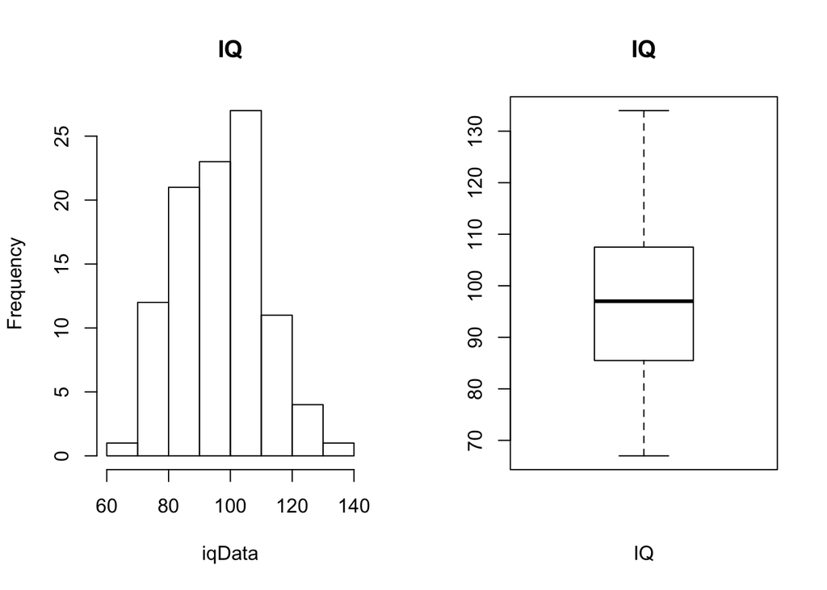

All samples for variable IQ result int P-value greater than $\alpha$ = 0.05 - therefore they have a normal distribution.

### Group A

```r
iqGroupAData = data$iloraz_intelig[data$grupa=='A']
```

```r
summary(iqGroupAData)
```

```
   Min. 1st Qu.  Median    Mean 3rd Qu.    Max.
   80.0   100.5   106.5   104.9   111.5   122.0
```

```r
descriptive_statistics(iqGroupAData, "IQ variable groupped for Group A")
```

```
variance 154.696428571429
```

```
standard dev 12.4377019007302
```

```
skewness -0.636340940511677 (jeżeli dodatnie to prawy brzeg jest dłuższy, jeżeli ujemne - to lewy)
```

```
kurtoza -0.511865761392951 + : wystaje ponad normalny; - : poniżej normalnego
```

```
shapiro: p-value:  0.593628360075638 (if p-value < 0.05 - NOT NORMAL)
```

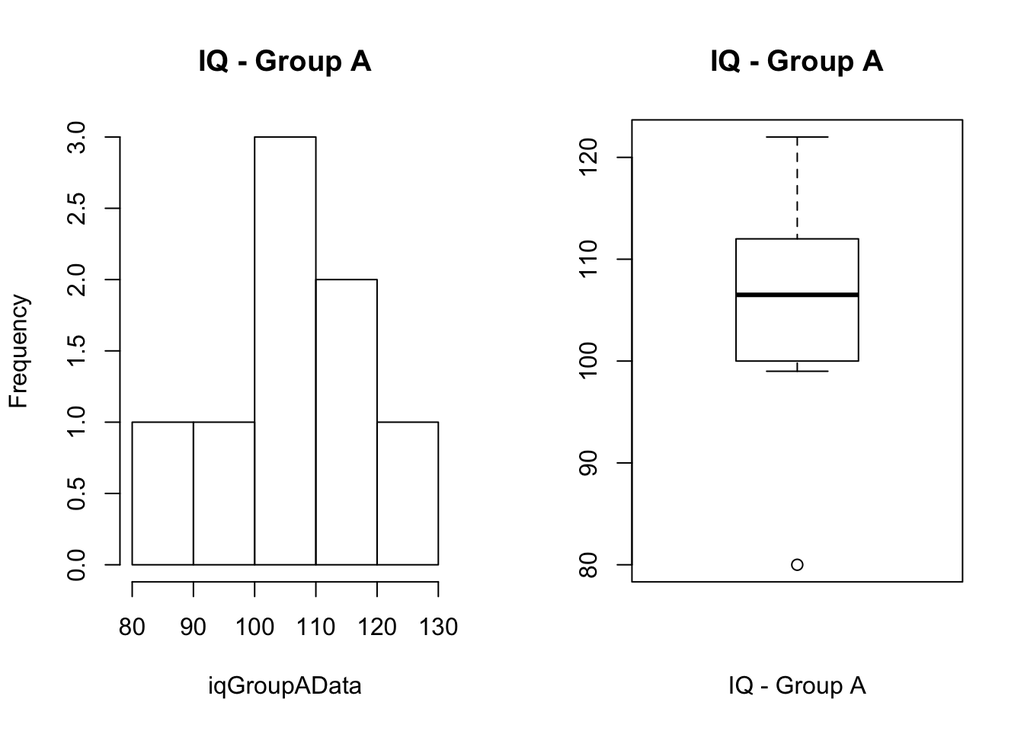

### Group B

```r
iqGroupBData = data$iloraz_intelig[data$grupa=='B']
```

```r
summary(iqGroupBData)
```

```
   Min. 1st Qu.  Median    Mean 3rd Qu.    Max.
  72.00   93.00  100.50   98.25  105.50  109.00
```

```r
descriptive_statistics(iqGroupBData, "IQ variable groupped for Group B")
```

```
variance 109.113636363636
```

```
standard dev 10.4457472860316
```

```
skewness -1.15968767806069 (jeżeli dodatnie to prawy brzeg jest dłuższy, jeżeli ujemne - to lewy)
```

```
kurtoza 0.602479849687347 + : wystaje ponad normalny; - : poniżej normalnego
```

```
shapiro: p-value:  0.056787250779079 (if p-value < 0.05 - NOT NORMAL)
```

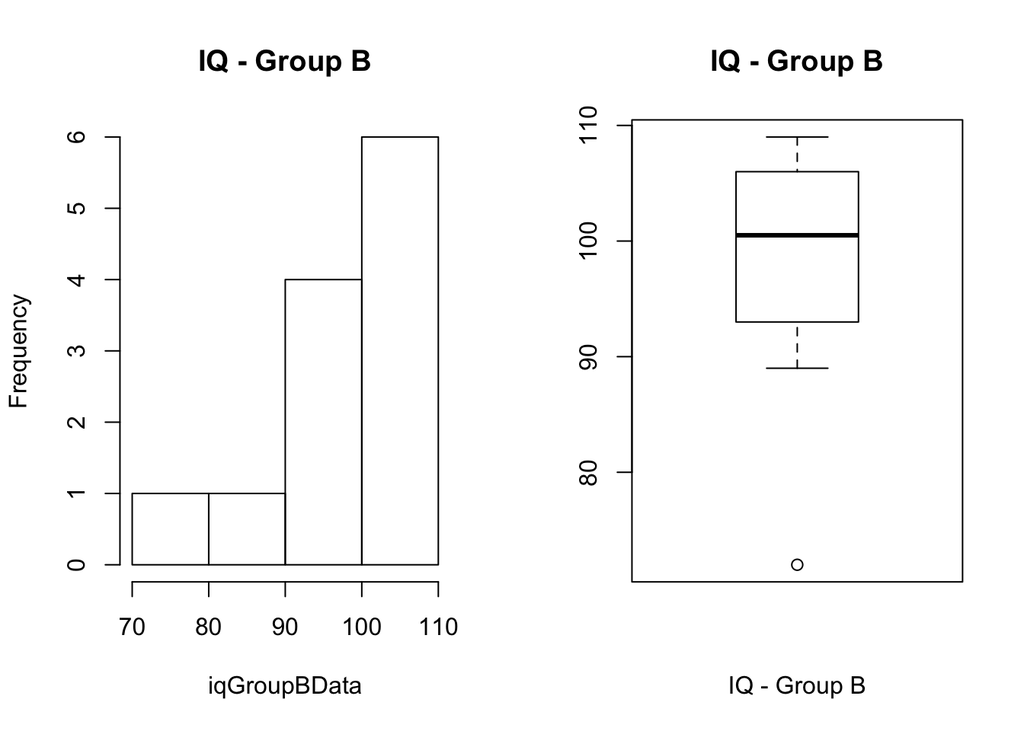

## Grades

```r
grades = data$oceny
grades = grades[!is.na(grades)]
```

### Ungroupped data

```r
summary(grades)
```

```
   Min. 1st Qu.  Median    Mean 3rd Qu.    Max.
  2.000   3.000   3.500   3.525   4.000   5.000
```

```r
descriptive_statistics(grades, "Grades variable for all samples")
```

```
variance 0.801973684210526
```

```
standard dev 0.89552983434977
```

```
skewness -0.17531017067566 (jeżeli dodatnie to prawy brzeg jest dłuższy, jeżeli ujemne - to lewy)
```

```
kurtoza -0.822696832218342 + : wystaje ponad normalny; - : poniżej normalnego
```

```
shapiro: p-value:  0.200116183030953 (if p-value < 0.05 - NOT NORMAL)
```

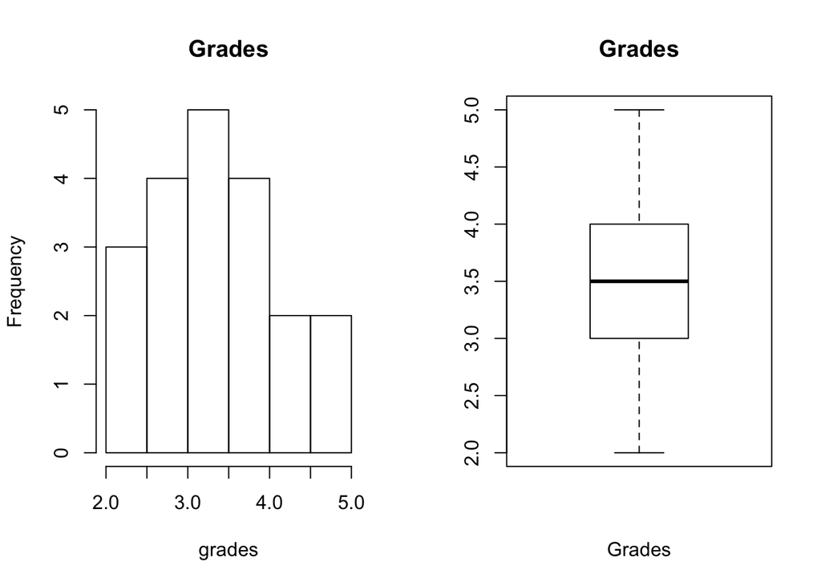

### Group A

```r
gradesGroupA = data$oceny[data$grupa=='A']
gradesGroupA = gradesGroupA[!is.na(gradesGroupA)]
```

```r
summary(gradesGroupA)
```

```
   Min. 1st Qu.  Median    Mean 3rd Qu.    Max.
  2.000   2.750   3.250   3.312   4.000   5.000
```

```r
descriptive_statistics(gradesGroupA, "Grades - Group  A")
```

```
variance 1.06696428571429
```

```
standard dev 1.0329396331414
```

```
skewness 0.0996845245652554 (jeżeli dodatnie to prawy brzeg jest dłuższy, jeżeli ujemne - to lewy)
```

```
kurtoza -1.40662447917578 + : wystaje ponad normalny; - : poniżej normalnego
```

```
shapiro: p-value:  0.621541925436456 (if p-value < 0.05 - NOT NORMAL)
```

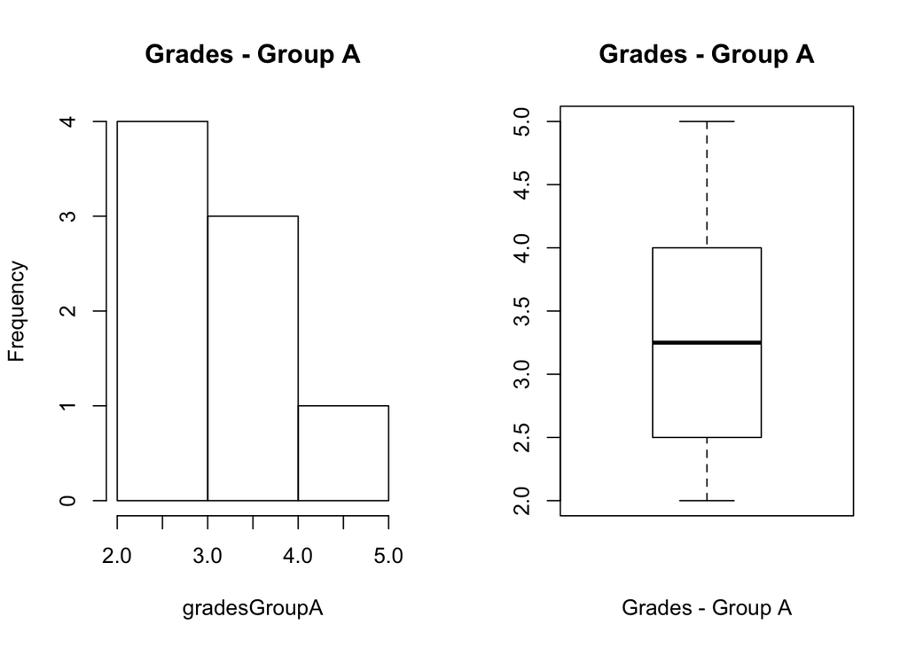

### Group B

```r
gradesGroupB = data$oceny[data$grupa=='B']
gradesGroupB = gradesGroupB[!is.na(gradesGroupB)]
```

```r
summary(gradesGroupB)
```

```
   Min. 1st Qu.  Median    Mean 3rd Qu.    Max.
  2.000   3.375   3.500   3.667   4.125   5.000
```

```r
descriptive_statistics(gradesGroupB, "Grades - Group  B")
```

```
variance 0.651515151515151
```

```
standard dev 0.807164884961649
```

```
skewness -0.259705701899279 (jeżeli dodatnie to prawy brzeg jest dłuższy, jeżeli ujemne - to lewy)
```

```
kurtoza -0.592324680007211 + : wystaje ponad normalny; - : poniżej normalnego
```

```
shapiro: p-value:  0.737556857059956 (if p-value < 0.05 - NOT NORMAL)
```

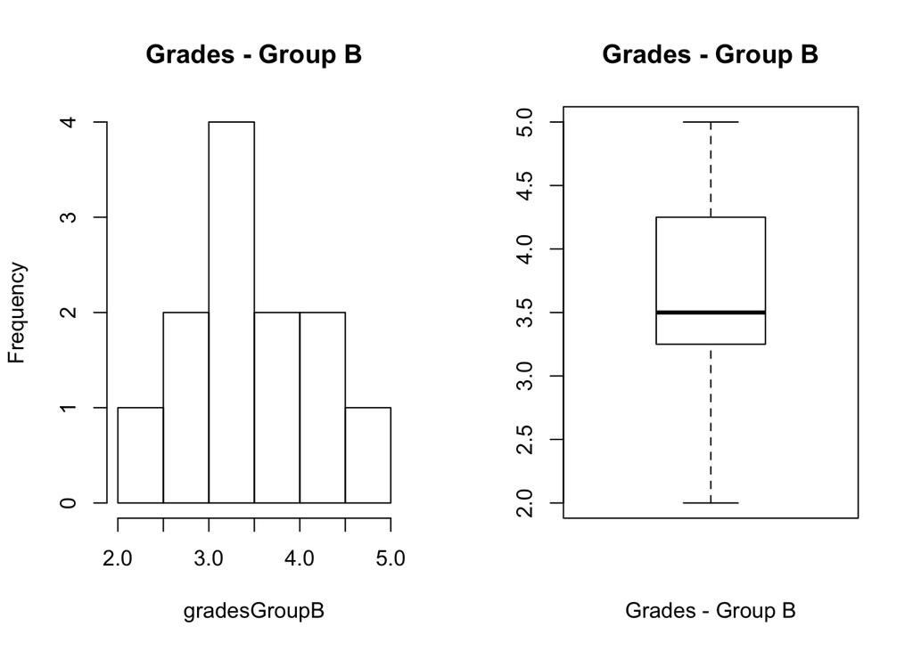

## Income

```r
income = data$zarobki
income = income[!is.na(income)]
```

### Ungroupped data

```r
summary(income)
```

```
   Min. 1st Qu.  Median    Mean 3rd Qu.    Max.
    600    1500    1800    3718    2200   40000
```

```r
descriptive_statistics(income, "Income variable for all samples")
```

```
variance 61636777.3333333
```

```
standard dev 7850.90933162098
```

```
skewness 3.9776498610461 (jeżeli dodatnie to prawy brzeg jest dłuższy, jeżeli ujemne - to lewy)
```

```
kurtoza 15.3005986972439 + : wystaje ponad normalny; - : poniżej normalnego
```

```
shapiro: p-value:  1.25005130097941e-09 (if p-value < 0.05 - NOT NORMAL)
```

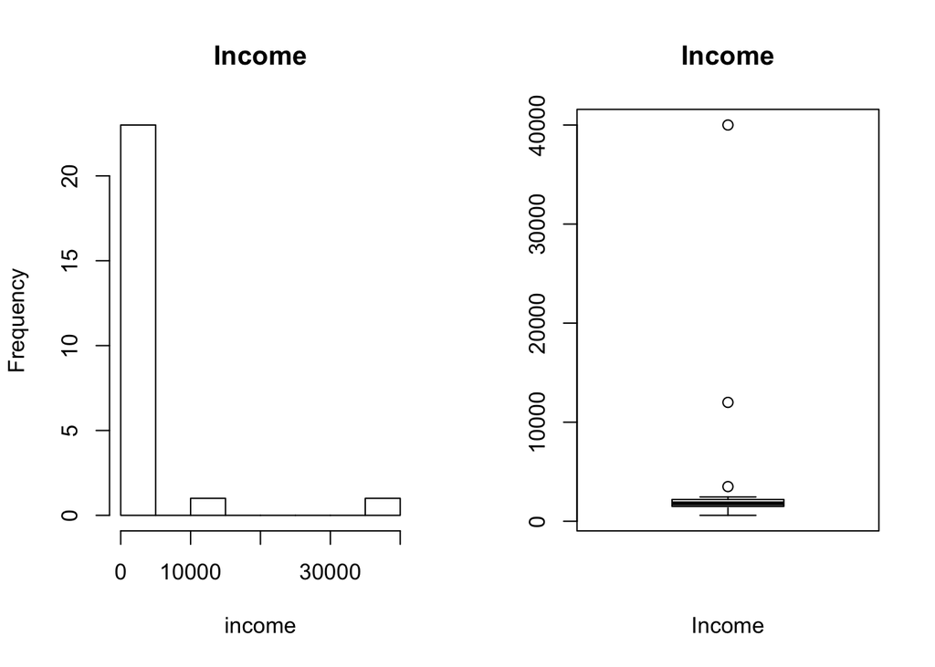

### Removing outliers

Since values 40 000 and 12 000 are outstanding ones, we are redoing the descriptive analysis without them

```r
income = income[!is.na(income) & income != 40000 & income != 12000]
```

```r
summary(income)
```

```
   Min. 1st Qu.  Median    Mean 3rd Qu.    Max.
    600    1500    1800    1780    2100    3500
```

```r
descriptive_statistics(income, "Income variable without outliers")
```

```
variance 360145.454545455
```

```
standard dev 600.121199880036
```

```
skewness 0.54171875389214 (jeżeli dodatnie to prawy brzeg jest dłuższy, jeżeli ujemne - to lewy)
```

```
kurtoza 1.05871947017579 + : wystaje ponad normalny; - : poniżej normalnego
```

```
shapiro: p-value:  0.337089365751282 (if p-value < 0.05 - NOT NORMAL)
```

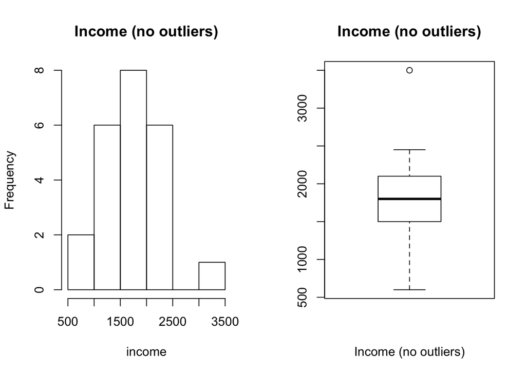

### Group A

```r
incomeGroupA = data$zarobki[data$grupa=='A']
incomeGroupA = incomeGroupA[!is.na(incomeGroupA)]

summary(incomeGroupA)
```

```
   Min. 1st Qu.  Median    Mean 3rd Qu.    Max.
    600    1500    1890    1898    2075    3500
```

```r
descriptive_statistics(incomeGroupA, "Income - Group A")
```

```
variance 679478.571428571
```

```
standard dev 824.30490198019
```

```
skewness 0.417602447001236 (jeżeli dodatnie to prawy brzeg jest dłuższy, jeżeli ujemne - to lewy)
```

```
kurtoza -0.426506097263498 + : wystaje ponad normalny; - : poniżej normalnego
```

```
shapiro: p-value:  0.534382538045862 (if p-value < 0.05 - NOT NORMAL)
```

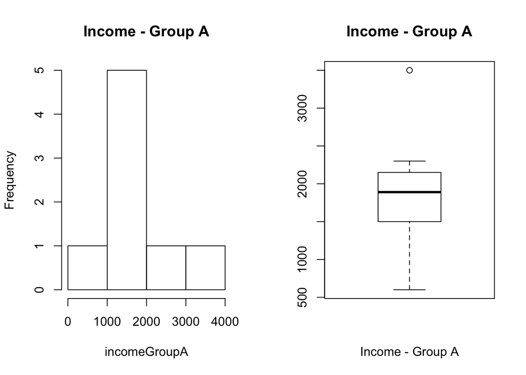

### Group B

```r
incomeGroupB = data$zarobki[data$grupa=='B']
incomeGroupB = incomeGroupB[!is.na(incomeGroupB)]

summary(incomeGroupB)
```

```
   Min. 1st Qu.  Median    Mean 3rd Qu.    Max.
   1250    1692    2050    2756    2200   12000
```

```r
descriptive_statistics(incomeGroupB, "Income - Group B")
```

```
variance 8582590.15151515
```

```
standard dev 2929.60580138611
```

```
skewness 2.58614295802334 (jeżeli dodatnie to prawy brzeg jest dłuższy, jeżeli ujemne - to lewy)
```

```
kurtoza 5.27416159472823 + : wystaje ponad normalny; - : poniżej normalnego
```

```
shapiro: p-value:  6.01253589596165e-06 (if p-value < 0.05 - NOT NORMAL)
```

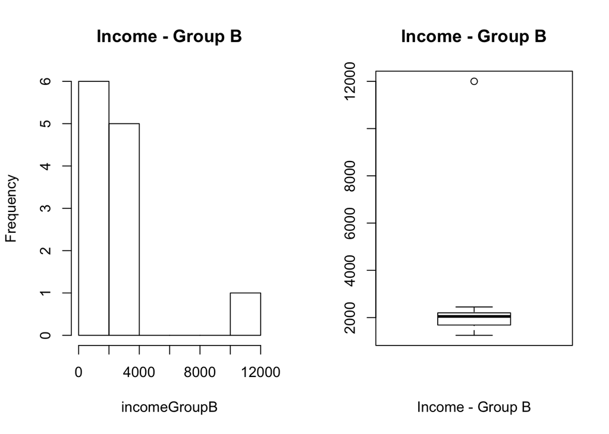

# Correlation check

For this excercise, we are considering ungroupped data entries.

```r
incomeWithoutOutliers = data[!data$zarobki %in% c(40000, 12000), ]
```

## IQ vs Income

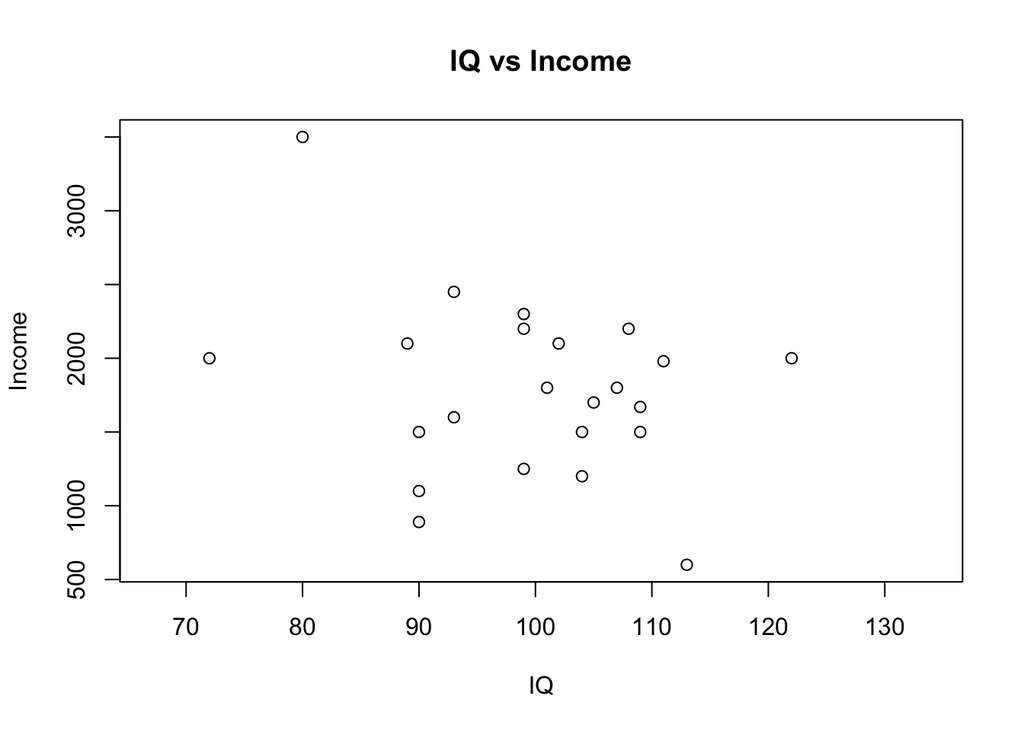

```r
plot(incomeWithoutOutliers$iloraz_intelig, incomeWithoutOutliers$zarobki, main = "IQ vs Income", xlab = "IQ", ylab = "Income")
```

## Grades vs Income

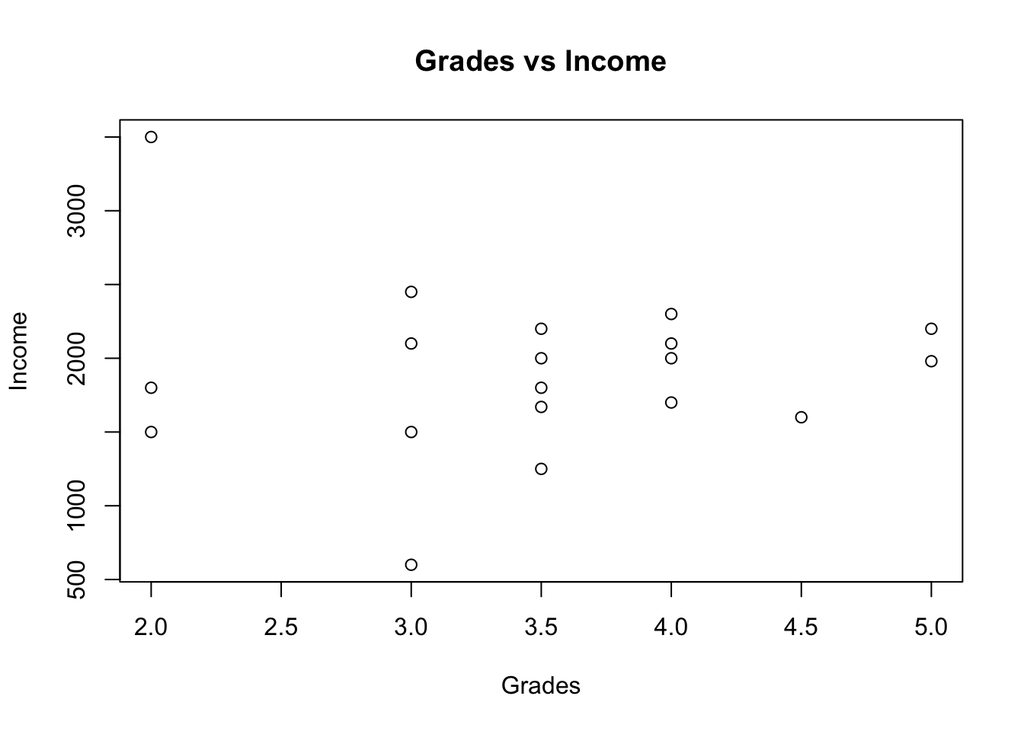

```r
plot(incomeWithoutOutliers$oceny, incomeWithoutOutliers$zarobki, main = "Grades vs Income", xlab = "Grades", ylab = "Income")
```

## IQ vs Grades

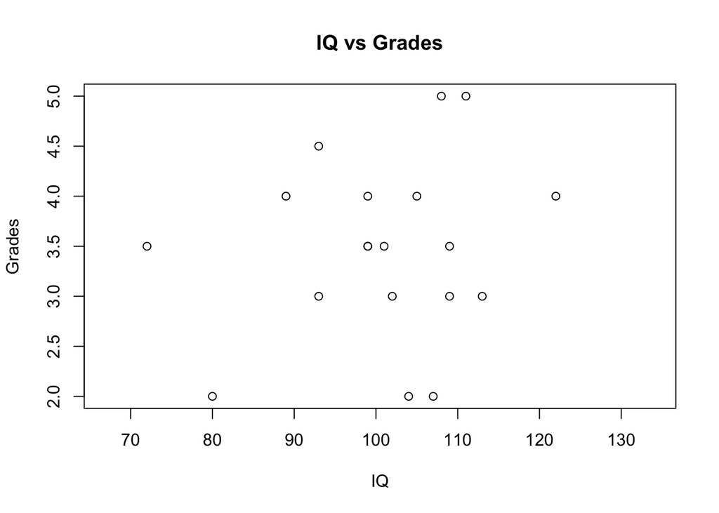

```r
plot(incomeWithoutOutliers$iloraz_intelig, incomeWithoutOutliers$oceny, main = "IQ vs Grades", xlab="IQ", ylab = "Grades")
```

From the plots above we can infer that there is no correlation between any of the variables. Please keep in mind that the groupping variable was not used here.